# Computer class 2 exercises

Richard Wilkinson

March 4 2016

## Question 1

The MASS package contains information on the birth weight of 189 babies. Let’s look at the difference between babies born to mothers who smoke and those whose mothers are non-smokers.

```r
library(MASS)
attach(birthwt)
bwt.smoke <- bwt[smoke==1]
bwt.nonsmoke <- bwt[smoke==0]
```

We’ll look below at whether the two groups have the same mean (which is the usual question of interest), but to begin with, test the null hypothesis
$$H_0: \sigma^2_{smoke} = \sigma^2_{nonsmoke}$$
against the alternative that

$$H_1: \sigma^2_{smoke} < \sigma^2_{nonsmoke}.$$
Note that a useful test statistic to use is
$$T = \frac{s_{smoke}}{s_{nonsmoke}}$$
where $s^2$ is the usual estimator of variance.

- Using a randomization test to test $H_0$ vs $H_1$. What do you conclude?
- What parametric test would you use to test these hypotheses?

## Question 2

Now assume that both distributions are Gaussian.

- Repeat the hypothesis test using a Monte Carlo test.
- Check the Gaussian assumption. Which of these three approaches (Monte Carlo, randomization, or classical tests) do you prefer? Which do you think is most trustworthy?

## Question 4

Perform a bootstrap hypothesis test to test whether the two populations have the same mean.

## Question 5

Use a randomization test to test
$$H_0: \mu_{bwt.smoke} = 2600$$
against the alternative
$$H_1: \mu_{bwt.smoke} \not = 2600$$

## Question 6

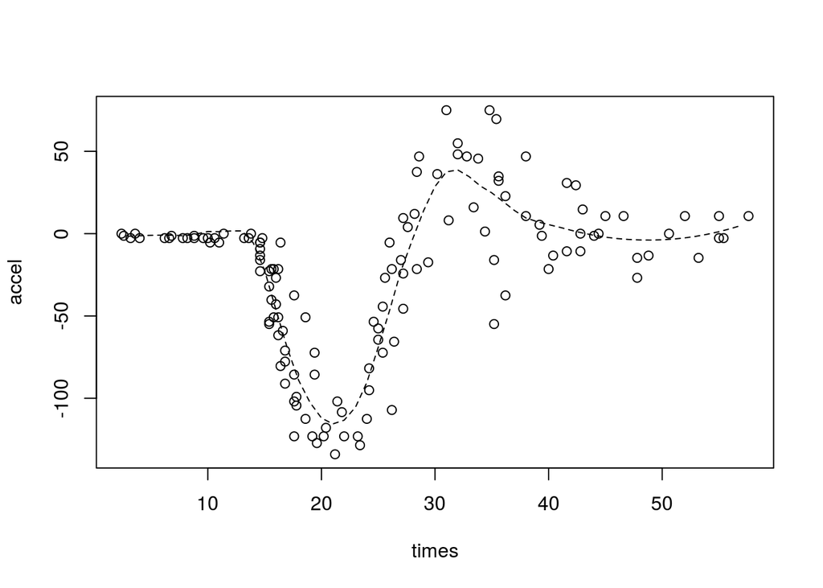

```r
library(MASS)
plot(mcycle)
fit <- loess(accel~times, mcycle, span=1/3)
times <- seq(0,70)
lines(times, predict(fit, times), lty=2)
```

The details aren’t important for this course, but for completeness, the span (set to 1/3 here) determines the proportion of the data to be included in the moving window specifying which points are to be regressed upon.

Because of the non-parametric structure of the model, classical approaches to the assessment of the parameter precision make no sense. However, we can get an estimate of the uncertainty in the fitted model prediction by bootstrapping.

Carry out a bootstrap estimate of the fitted line by

- bootstrapping pairs $(x,y)$ from the original data
- refitting the `loess` curve
- You can then get a sense of uncertainty by plotting all of the fitted curves on top of the data.

Find a 95% confidence interval for the range of accelerations we expect to see 35ms into the collision.